# Tiling

Bradford Condon

October 20, 2016

# Overview

Goal:

Categorize recombination within the genome.

We want to identify SNP-dense regions that are (high SNP within-clade) and (low SNP out-clade).

To do this, I will either use the shell of my sliding window script in perl, or write a new function in R.

Once windows are identified, I want to plot them on the scaffolds, **colored by strain**.

Note: FLTB refers to Festuca,Lolium, Triticum, Bromus. Any strains grouping in *either* of the wheat blast clades are placed in the FLTB clade for this analysis. This is desireable for looking for recombination events/ regions that are most similar to non-wheat blast isolates.

## Source data

the loadData.R script reads in SNP report sheets generated by the SNP-finder algorithm developed by Dr. Mark Farman. This currently points at directories on my local machine and will need to be modified for use elsewhere (and for new SNP reports).

```r
#load dependencies etc
library(plyr)
```

```r
library(ggplot2)
library(knitr)
library(dplyr)
source("R/helperFunctions.R")
```

```r
#load image created by LoadData.R
load("IA1andBR80ReadSNPs.RDATA")
```

## Summarizing scaffolds

First, let’s summarize scaffolds based on SNPs by clade. This will allow me to develop the sorts of methods I’ll use once windows are defined

```r
#first, sum number of SNPs for each file for each scaffold
snpsGrouped <- summarise(group_by(br80AllSnpDF, scaffoldRef, fileName, Clade), SNPs = n())
#now, take the average for each scaffold
snpsAvg <- summarise(group_by(snpsGrouped, fileName), average = mean(SNPs), SD = sd(SNPs))
kable(snpsAvg)
```

| fileName | average | SD |
| --- | --- | --- |
| Arcadia | 544.3771 | 994.3154 |
| B2 | 224.8908 | 515.8155 |
| B51 | 415.1444 | 859.8786 |
| B71 | 247.5683 | 603.5760 |
| Bd8401 | 548.3156 | 987.8790 |
| Bm88324 | 569.9360 | 834.9272 |
| Br130 | 146.6037 | 459.4875 |
| Br7 | 233.0231 | 590.6865 |
| CHRF | 292.7939 | 702.0715 |
| CHW | 288.8065 | 696.3594 |
| DsLIZ | 5712.1914 | 9353.0769 |
| FH | 265.7770 | 660.8818 |
| FR13 | 519.0626 | 966.5205 |
| G17_2M | 549.5154 | 970.4445 |
| GG11 | 279.3239 | 681.1376 |
| GRF52 | 542.2894 | 1004.1211 |
| Guy11 | 528.7952 | 973.0316 |
| HO | 277.6370 | 680.0388 |
| IA1 | 523.4701 | 965.3138 |
| IB33 | 524.9788 | 967.9909 |
| IB49 | 530.0253 | 967.4264 |
| IC17 | 522.1696 | 963.5718 |
| IE1K | 520.7897 | 962.1261 |
| LpKY97 | 253.0171 | 650.0113 |
| ML33 | 523.8073 | 970.1335 |
| P131 | 520.9904 | 962.7194 |
| P28 | 259.8113 | 687.4657 |
| P29 | 201.7922 | 515.8067 |
| P3 | 193.1226 | 476.4472 |
| PgKY | 300.9114 | 708.1224 |
| PH42 | 390.9755 | 825.2167 |
| PL2-1 | 284.2090 | 685.1930 |
| PL3-1 | 279.7130 | 692.6498 |
| PY86 | 307.7919 | 721.2305 |
| SSFL14-3 | 525.4523 | 824.0199 |
| T25 | 258.2160 | 559.2104 |
| TF05-1 | 296.8239 | 674.7723 |
| WBKY | 277.2244 | 696.3087 |
| WHTQ | 233.0253 | 581.5606 |
| Y34 | 527.6335 | 969.2160 |

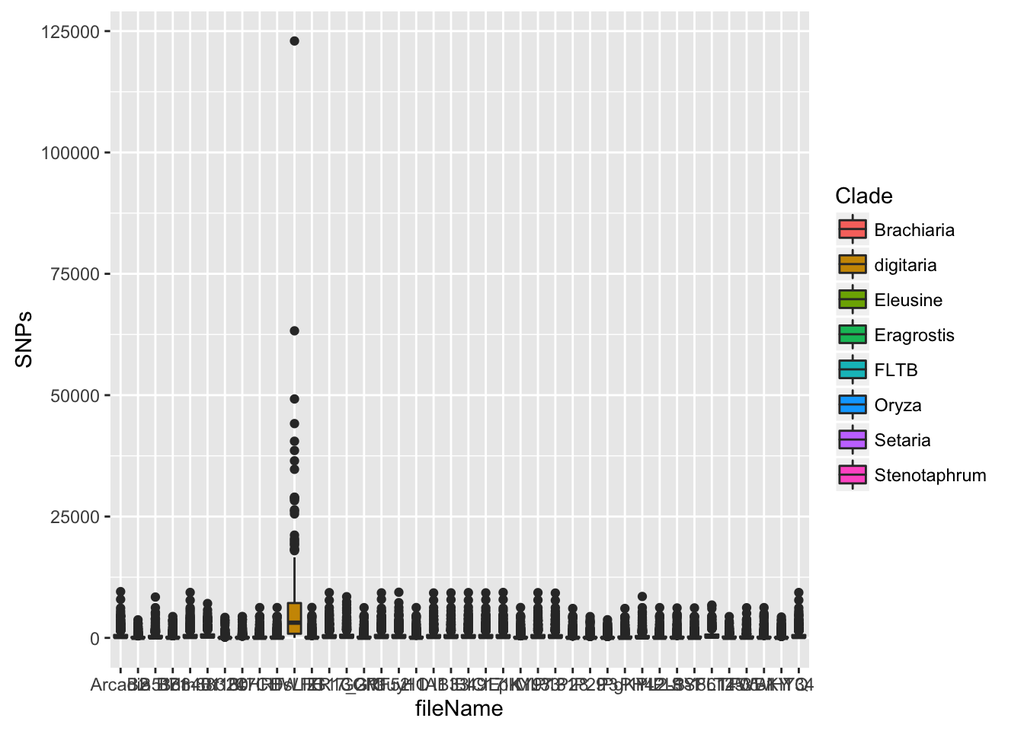

```r
#Plot this in whiskerplot form

ggplot(snpsGrouped, aes(x= fileName, y = SNPs, fill= Clade)) + geom_boxplot()
```

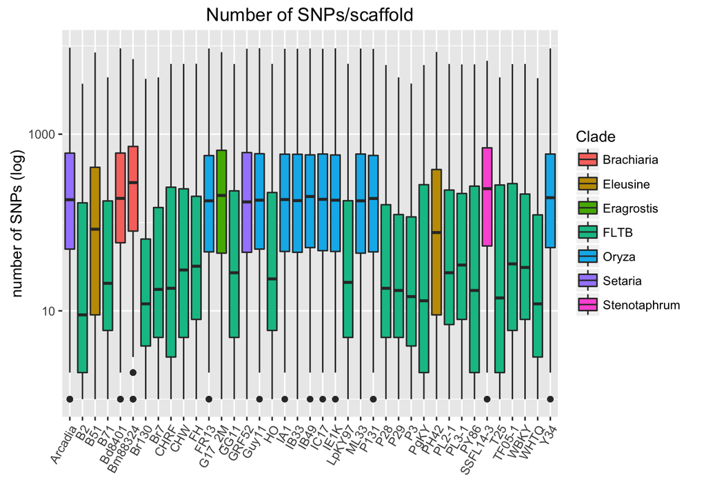

```r
#digitaria skews the plot too much: remove

snpsGrouped2 <- filter(snpsGrouped, Clade != 'digitaria')
ggplot(snpsGrouped2, aes(x= fileName, y = SNPs, fill= Clade)) + geom_boxplot()+ scale_y_log10()+ggtitle("Number of SNPs/scaffold")+ ylab("number of SNPs (log)") +  theme(axis.text.x = element_text(angle = 60, hjust = 1)) + xlab("")
```

We can see that the FLTB isolates have lower SNPs/scaffold. Overall this plot isn’t that informative because it isn’t scaled by scaffold size. We can transform the number of SNPs into SNPs/kb.

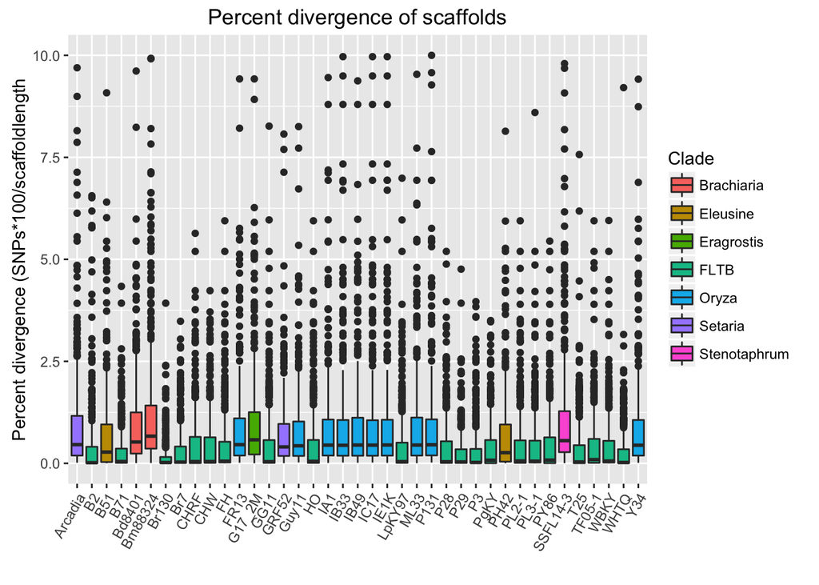

```r
#change to character, merge
br80lengths$scaffoldRef<- as.character(br80lengths$scaffold)
snpsGrouped2$scaffoldRef<- as.character(snpsGrouped2$scaffoldRef)
total <- merge(br80lengths,snpsGrouped2,by="scaffoldRef")

totalPercent<- mutate(total, scaledSNPs = SNPs * 100/ ( as.numeric(length)))
ggplot(totalPercent, aes(x= fileName, y = scaledSNPs, fill= Clade)) + geom_boxplot()+ggtitle("Percent divergence of scaffolds")+ ylab("Percent divergence (SNPs*100/scaffoldlength") +  theme(axis.text.x = element_text(angle = 60, hjust = 1)) + xlab("")+scale_y_continuous(limits = c(0, 10))
```

```r
totalPercent<- group_by(totalPercent, Clade)
statsByClade<- summarise(totalPercent, meanSNPs = mean(scaledSNPs), SD = sd(scaledSNPs), medianSNPs = median(scaledSNPs))

kable(statsByClade)
```

| Clade | meanSNPs | SD | medianSNPs |
| --- | --- | --- | --- |
| Brachiaria | 1.0480386 | 1.310382 | 0.5888725 |
| Eleusine | 0.6638799 | 1.031030 | 0.2719682 |
| Eragrostis | 0.9794937 | 1.382103 | 0.5768406 |
| FLTB | 0.4217975 | 0.828416 | 0.0398278 |
| Oryza | 0.8596069 | 1.233096 | 0.4486803 |
| Setaria | 0.8222289 | 1.160394 | 0.4334362 |
| Stenotaphrum | 1.0418065 | 1.406932 | 0.5565093 |

## Definding windows

Next- we want to create windows, and score those windows based on number of SNPs by clade. In particular, we want to know

- Max SNPs/window/clade
- Min SNPs/window/clade
- Clade which had min SNP value?

This is done in the createSlidingWindows.R script.

# Analyzing sliding windows

To help with scoring the sliding windows, we need to ask some basic questions about them.

- What is the distribution of number of SNPs per window for each clade?

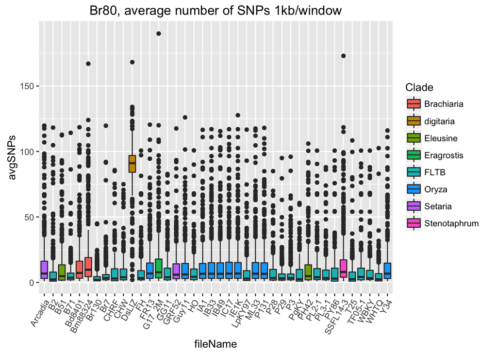

```r
#load sliding windows
load("br80Windows_v3_1kb.robj")

snpsGrouped <- summarise(group_by(br80WindowsDF, Scaffold, fileName, Clade), avgSNPs = mean(count))

ggplot(data = snpsGrouped, aes(x=fileName, y = avgSNPs, fill = Clade))+ geom_boxplot()+ theme(axis.text.x = element_text(angle = 60, hjust = 1)) +ggtitle("Br80, average number of SNPs 1kb/window")
```

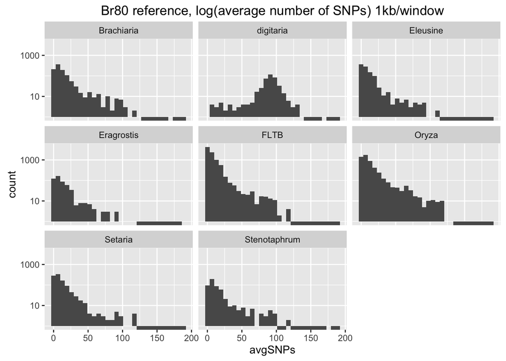

```r
ggplot(data = snpsGrouped, aes(x=avgSNPs))+ geom_histogram()+ggtitle("Br80 reference, log(average number of SNPs) 1kb/window")+facet_wrap(~Clade, nrow = 3)+scale_y_log10()
```

# scoring sliding windows

Critical! Right now the script does the following *for each window region*:

Possible big change to make: There is no minimum number of SNPs to consider a scaffold. If we’re interested in SNP-dense regions, want to set some sort of minimum. But compared to which strains/clades? All of them? Just FLTB?

(Need minimum number of SNPs in wheat BLAST)

Issue: sometimes, clades are tied for minimum. IE brachiara and Oryza will both have only 1 SNP. what then?

```r
allScaffoldsTracker<- br80WindowsDF
#let's classify each window as being "outsourced or not".
#I'm going to do define this as a minimum "out" distance being LESS than the average "in" distance
#Final out is going to be
#scaffold - window pos - in/out - number of snps

dfTracker <- data.frame(Scaffold=NA, window=NA, match=NA, value = NA, stringsAsFactors = FALSE)[numeric(0), ]
loop = c(1:length(allScaffoldsTracker)) #make sure this s valid!
for (i in loop){
  thisScaffold <- allScaffoldsTracker[[i]]
  thisScaffoldName <- allScaffoldsTracker[i]
  loopTwo = c(1:length(thisScaffold))
  for (j in loopTwo){
    thisWindow <- thisScaffold[[j]]
     thisWindow<-  group_by(thisWindow, Clade)
     windowSum<- summarise(thisWindow, avg = mean(count), min = min(count), max = max(count))
   FLTB <- filter(windowSum, Clade == 'FLTB'  ) #just FLTB
   notFLTB <- arrange(filter(windowSum, Clade != 'FLTB'  ), min)[1,]#lowest minimum, not FLTB
   windowLoc<- names(thisScaffold)[j]
   windowRange <- paste( windowLoc, "-", as.numeric(windowLoc) + windowSize, sep="")
       if(nrow(notFLTB)  ==0) {   #If no FLTB snps, assume FLTB is best match
         dfTracker <- rbind(dfTracker, data.frame(Scaffold=thisScaffoldName, window=windowRange, match="FLTB", value=0 ))
         next }
   if (is.na(notFLTB[1,1]) | is.na(FLTB[1,1])){next }
   else if (notFLTB[3] < FLTB[2] ){ #if the lowest number of SNPs  not in FLTB is less than the average FLTB snps...
      dfTracker <- rbind(dfTracker, data.frame(Scaffold=thisScaffoldName, window=windowRange, match=notFLTB$Clade[1], value=notFLTB$min[1] ))
   }
   else if (notFLTB[3] > FLTB[2] ){ #
         dfTracker <- rbind(dfTracker, data.frame(Scaffold=thisScaffoldName, window=windowRange, match=FLTB$Clade[1], value=FLTB$avg[1] ))

    }
  }
}
```

# Summarizing scaffolds

```r
#group by scaffold
     ScaffoldSummary<-  group_by(dfTracker, Scaffold, match)

 sumLongForm <- summarise(ScaffoldSummary,count = n(),  avg_SNP = mean(value))

ScaffoldSummaryShort<-  group_by(dfTracker, match)

sumShortForm <- summarise(ScaffoldSummaryShort,count = n() )

 kable(sumShortForm)

 windowsGrouped <- summarise(group_by(dfTracker, Scaffold, match), windowNumber = n())

ggplot(windowsGrouped, aes(x= match, y = windowNumber)) + geom_boxplot()
```

[output not shown]

# Plotting windows

```r
#Convert window character to numeric
dfTracker$window<- as.numeric(gsub( "-.*", "", x= as.character(dfTracker$window)))
##Loop through every scaffold, print to a PDF.
scaffoldList <- as.character((unique(dfTracker$Scaffold)))
pdf("br80_5kwindows.pdf", 8.5, 11)
for (i in scaffoldList){
scaffToPlot<- subset(dfTracker, Scaffold == i)
title <- paste("br80", i)
p<- ggplot(scaffToPlot, aes(x=window, fill = match)) +  ggtitle(title)+xlab("Br80 position")+ geom_histogram()
plot(p)
}
dev.off()
```